# Chiara homework week 10 day 3

# MPV

```r
library(tidyverse)
library(modelr)
# visualisation packages
library(GGally)
library(ggfortify)
```

## 1. You are given a set of data on housing sale prices for the last few years in King County (near Seattle) between May 2014 and May 2015.

```r
housing_prices <- read_csv("data/kc_house_data.csv")
housing_prices
```

| id | date | price | bedrooms | bathrooms | sqft_living | sqft_lot | floors | waterfront | view | condition | grade | sqft_above | sqft_basement | yr_built | yr_renovated | zipcode | lat | long | sqft_living15 | sqft_lot15 |
| --- | --- | --- | --- | --- | --- | --- | --- | --- | --- | --- | --- | --- | --- | --- | --- | --- | --- | --- | --- | --- |
| 7129300520 | 2014-10-13 | 221900 | 3 | 1.00 | 1180 | 5650 | 1.0 | 0 | 0 | 3 | 7 | 1180 | 0 | 1955 | 0 | 98178 | 47.5112 | -122.257 | 1340 | 5650 |
| 6414100192 | 2014-12-09 | 538000 | 3 | 2.25 | 2570 | 7242 | 2.0 | 0 | 0 | 3 | 7 | 2170 | 400 | 1951 | 1991 | 98125 | 47.7210 | -122.319 | 1690 | 7639 |
| 5631500400 | 2015-02-25 | 180000 | 2 | 1.00 | 770 | 10000 | 1.0 | 0 | 0 | 3 | 6 | 770 | 0 | 1933 | 0 | 98028 | 47.7379 | -122.233 | 2720 | 8062 |
| 2487200875 | 2014-12-09 | 604000 | 4 | 3.00 | 1960 | 5000 | 1.0 | 0 | 0 | 5 | 7 | 1050 | 910 | 1965 | 0 | 98136 | 47.5208 | -122.393 | 1360 | 5000 |
| 1954400510 | 2015-02-18 | 510000 | 3 | 2.00 | 1680 | 8080 | 1.0 | 0 | 0 | 3 | 8 | 1680 | 0 | 1987 | 0 | 98074 | 47.6168 | -122.045 | 1800 | 7503 |
| 7237550310 | 2014-05-12 | 1225000 | 4 | 4.50 | 5420 | 101930 | 1.0 | 0 | 0 | 3 | 11 | 3890 | 1530 | 2001 | 0 | 98053 | 47.6561 | -122.005 | 4760 | 101930 |
| 1321400060 | 2014-06-27 | 257500 | 3 | 2.25 | 1715 | 6819 | 2.0 | 0 | 0 | 3 | 7 | 1715 | 0 | 1995 | 0 | 98003 | 47.3097 | -122.327 | 2238 | 6819 |
| 2008000270 | 2015-01-15 | 291850 | 3 | 1.50 | 1060 | 9711 | 1.0 | 0 | 0 | 3 | 7 | 1060 | 0 | 1963 | 0 | 98198 | 47.4095 | -122.315 | 1650 | 9711 |
| 2414600126 | 2015-04-15 | 229500 | 3 | 1.00 | 1780 | 7470 | 1.0 | 0 | 0 | 3 | 7 | 1050 | 730 | 1960 | 0 | 98146 | 47.5123 | -122.337 | 1780 | 8113 |
| 3793500160 | 2015-03-12 | 323000 | 3 | 2.50 | 1890 | 6560 | 2.0 | 0 | 0 | 3 | 7 | 1890 | 0 | 2003 | 0 | 98038 | 47.3684 | -122.031 | 2390 | 7570 |

[output cut: 990 more lines]

```r
glimpse(housing_prices)
```

```
Rows: 21,613
Columns: 21
$ id            <chr> "7129300520", "6414100192", "5631500400", "2487200875", "1954400510", "7237550310", "1321400060", "2008000270", "24146…
$ date          <dttm> 2014-10-13, 2014-12-09, 2015-02-25, 2014-12-09, 2015-02-18, 2014-05-12, 2014-06-27, 2015-01-15, 2015-04-15, 2015-03-1…
$ price         <dbl> 221900, 538000, 180000, 604000, 510000, 1225000, 257500, 291850, 229500, 323000, 662500, 468000, 310000, 400000, 53000…
$ bedrooms      <dbl> 3, 3, 2, 4, 3, 4, 3, 3, 3, 3, 3, 2, 3, 3, 5, 4, 3, 4, 2, 3, 4, 3, 5, 2, 3, 3, 3, 3, 3, 4, 3, 2, 4, 3, 4, 3, 4, 4, 4, 4…
$ bathrooms     <dbl> 1.00, 2.25, 1.00, 3.00, 2.00, 4.50, 2.25, 1.50, 1.00, 2.50, 2.50, 1.00, 1.00, 1.75, 2.00, 3.00, 2.00, 1.00, 1.00, 1.00…
$ sqft_living   <dbl> 1180, 2570, 770, 1960, 1680, 5420, 1715, 1060, 1780, 1890, 3560, 1160, 1430, 1370, 1810, 2950, 1890, 1600, 1200, 1250,…
$ sqft_lot      <dbl> 5650, 7242, 10000, 5000, 8080, 101930, 6819, 9711, 7470, 6560, 9796, 6000, 19901, 9680, 4850, 5000, 14040, 4300, 9850,…
$ floors        <dbl> 1.0, 2.0, 1.0, 1.0, 1.0, 1.0, 2.0, 1.0, 1.0, 2.0, 1.0, 1.0, 1.5, 1.0, 1.5, 2.0, 2.0, 1.5, 1.0, 1.0, 1.0, 1.0, 2.0, 1.0…
$ waterfront    <dbl> 0, 0, 0, 0, 0, 0, 0, 0, 0, 0, 0, 0, 0, 0, 0, 0, 0, 0, 0, 0, 0, 0, 0, 0, 0, 0, 0, 0, 0, 0, 0, 0, 0, 0, 0, 0, 0, 0, 0, 0…
$ view          <dbl> 0, 0, 0, 0, 0, 0, 0, 0, 0, 0, 0, 0, 0, 0, 0, 3, 0, 0, 0, 0, 0, 4, 0, 0, 0, 0, 0, 0, 0, 0, 0, 0, 0, 0, 0, 0, 0, 0, 0, 0…
$ condition     <dbl> 3, 3, 3, 5, 3, 3, 3, 3, 3, 3, 3, 4, 4, 4, 3, 3, 3, 4, 4, 4, 4, 3, 3, 3, 4, 5, 3, 5, 3, 3, 3, 3, 4, 4, 3, 3, 1, 4, 2, 3…
$ grade         <dbl> 7, 7, 6, 7, 8, 11, 7, 7, 7, 7, 8, 7, 7, 7, 7, 9, 7, 7, 7, 7, 7, 9, 8, 7, 8, 6, 8, 8, 7, 8, 8, 7, 7, 8, 7, 8, 5, 8, 7, …
$ sqft_above    <dbl> 1180, 2170, 770, 1050, 1680, 3890, 1715, 1060, 1050, 1890, 1860, 860, 1430, 1370, 1810, 1980, 1890, 1600, 1200, 1250, …
$ sqft_basement <dbl> 0, 400, 0, 910, 0, 1530, 0, 0, 730, 0, 1700, 300, 0, 0, 0, 970, 0, 0, 0, 0, 760, 720, 0, 0, 0, 0, 700, 0, 730, 0, 0, 0…
$ yr_built      <dbl> 1955, 1951, 1933, 1965, 1987, 2001, 1995, 1963, 1960, 2003, 1965, 1942, 1927, 1977, 1900, 1979, 1994, 1916, 1921, 1969…
$ yr_renovated  <dbl> 0, 1991, 0, 0, 0, 0, 0, 0, 0, 0, 0, 0, 0, 0, 0, 0, 0, 0, 0, 0, 0, 0, 0, 0, 0, 0, 0, 0, 0, 0, 0, 0, 0, 0, 0, 2002, 0, 0…
$ zipcode       <dbl> 98178, 98125, 98028, 98136, 98074, 98053, 98003, 98198, 98146, 98038, 98007, 98115, 98028, 98074, 98107, 98126, 98019,…
$ lat           <dbl> 47.5112, 47.7210, 47.7379, 47.5208, 47.6168, 47.6561, 47.3097, 47.4095, 47.5123, 47.3684, 47.6007, 47.6900, 47.7558, 4…
$ long          <dbl> -122.257, -122.319, -122.233, -122.393, -122.045, -122.005, -122.327, -122.315, -122.337, -122.031, -122.145, -122.292…
$ sqft_living15 <dbl> 1340, 1690, 2720, 1360, 1800, 4760, 2238, 1650, 1780, 2390, 2210, 1330, 1780, 1370, 1360, 2140, 1890, 1610, 1060, 1280…
$ sqft_lot15    <dbl> 5650, 7639, 8062, 5000, 7503, 101930, 6819, 9711, 8113, 7570, 8925, 6000, 12697, 10208, 4850, 4000, 14018, 4300, 5095,…
```

```r
skimr::skim(housing_prices)
```

```
── Data Summary ────────────────────────
                           Values
Name                       housing_prices
Number of rows             21613
Number of columns          21
_______________________
Column type frequency:
  character                1
  numeric                  19
  POSIXct                  1
________________________
Group variables            None
```

|  | skim_variable | n_missing | complete_rate | min | max | empty | n_unique | whitespace |
| --- | --- | --- | --- | --- | --- | --- | --- | --- |
| 1 | id | 0 | 1 | 10 | 10 | 0 | 21436 | 0 |

|  | skim_variable | n_missing | complete_rate | mean | sd | p0 | p25 | p50 | p75 | p100 | hist |
| --- | --- | --- | --- | --- | --- | --- | --- | --- | --- | --- | --- |
| 1 | price | 0 | 1 | 5.400881e+05 | 3.671272e+05 | 75000.0000 | 321950.000 | 450000.0000 | 645000.000 | 7700000.0000 | ▇▁▁▁▁ |
| 2 | bedrooms | 0 | 1 | 3.370842e+00 | 9.300618e-01 | 0.0000 | 3.000 | 3.0000 | 4.000 | 33.0000 | ▇▁▁▁▁ |
| 3 | bathrooms | 0 | 1 | 2.114757e+00 | 7.701632e-01 | 0.0000 | 1.750 | 2.2500 | 2.500 | 8.0000 | ▃▇▁▁▁ |
| 4 | sqft_living | 0 | 1 | 2.079900e+03 | 9.184409e+02 | 290.0000 | 1427.000 | 1910.0000 | 2550.000 | 13540.0000 | ▇▂▁▁▁ |
| 5 | sqft_lot | 0 | 1 | 1.510697e+04 | 4.142051e+04 | 520.0000 | 5040.000 | 7618.0000 | 10688.000 | 1651359.0000 | ▇▁▁▁▁ |
| 6 | floors | 0 | 1 | 1.494309e+00 | 5.399889e-01 | 1.0000 | 1.000 | 1.5000 | 2.000 | 3.5000 | ▇▅▁▁▁ |
| 7 | waterfront | 0 | 1 | 7.541757e-03 | 8.651720e-02 | 0.0000 | 0.000 | 0.0000 | 0.000 | 1.0000 | ▇▁▁▁▁ |
| 8 | view | 0 | 1 | 2.343034e-01 | 7.663176e-01 | 0.0000 | 0.000 | 0.0000 | 0.000 | 4.0000 | ▇▁▁▁▁ |
| 9 | condition | 0 | 1 | 3.409430e+00 | 6.507430e-01 | 1.0000 | 3.000 | 3.0000 | 4.000 | 5.0000 | ▁▁▇▃▁ |
| 10 | grade | 0 | 1 | 7.656873e+00 | 1.175459e+00 | 1.0000 | 7.000 | 7.0000 | 8.000 | 13.0000 | ▁▁▇▂▁ |

[output cut: 9 more lines]

|  | skim_variable | n_missing | complete_rate | min | max | median | n_unique |
| --- | --- | --- | --- | --- | --- | --- | --- |
| 1 | date | 0 | 1 | 2014-05-02 | 2015-05-27 | 2014-10-16 | 372 |

```r
housing_prices %>%
  summarise(across(.col = everything(), .fns = ~sum(is.na(.x))))
```

| id | date | price | bedrooms | bathrooms | sqft_living | sqft_lot | floors | waterfront | view | condition | grade | sqft_above | sqft_basement | yr_built | yr_renovated | zipcode | lat | long | sqft_living15 | sqft_lot15 |
| --- | --- | --- | --- | --- | --- | --- | --- | --- | --- | --- | --- | --- | --- | --- | --- | --- | --- | --- | --- | --- |
| 0 | 0 | 0 | 0 | 0 | 0 | 0 | 0 | 0 | 0 | 0 | 0 | 0 | 0 | 0 | 0 | 0 | 0 | 0 | 0 | 0 |

There are no missing values!

## 2. Tidy up the data ready for regression:

- I am going to remove all of `date`, `id`, `sqft_living15`, `sqft_lot15` and `zipcode`. I would also remove `sqft_above` and `sqft_basement`, because I think they are not relevant if we already have `sqft_living` and `sqft_lot`.

```r
housing_prices_trim <- housing_prices %>%
  select(-c("date", "id", "sqft_living15", "sqft_lot15", "zipcode", "sqft_above", "sqft_basement"))

housing_prices_trim
```

| price | bedrooms | bathrooms | sqft_living | sqft_lot | floors | waterfront | view | condition | grade | yr_built | yr_renovated | lat | long |
| --- | --- | --- | --- | --- | --- | --- | --- | --- | --- | --- | --- | --- | --- |
| 221900 | 3 | 1.00 | 1180 | 5650 | 1.0 | 0 | 0 | 3 | 7 | 1955 | 0 | 47.5112 | -122.257 |
| 538000 | 3 | 2.25 | 2570 | 7242 | 2.0 | 0 | 0 | 3 | 7 | 1951 | 1991 | 47.7210 | -122.319 |
| 180000 | 2 | 1.00 | 770 | 10000 | 1.0 | 0 | 0 | 3 | 6 | 1933 | 0 | 47.7379 | -122.233 |
| 604000 | 4 | 3.00 | 1960 | 5000 | 1.0 | 0 | 0 | 5 | 7 | 1965 | 0 | 47.5208 | -122.393 |
| 510000 | 3 | 2.00 | 1680 | 8080 | 1.0 | 0 | 0 | 3 | 8 | 1987 | 0 | 47.6168 | -122.045 |
| 1225000 | 4 | 4.50 | 5420 | 101930 | 1.0 | 0 | 0 | 3 | 11 | 2001 | 0 | 47.6561 | -122.005 |
| 257500 | 3 | 2.25 | 1715 | 6819 | 2.0 | 0 | 0 | 3 | 7 | 1995 | 0 | 47.3097 | -122.327 |
| 291850 | 3 | 1.50 | 1060 | 9711 | 1.0 | 0 | 0 | 3 | 7 | 1963 | 0 | 47.4095 | -122.315 |
| 229500 | 3 | 1.00 | 1780 | 7470 | 1.0 | 0 | 0 | 3 | 7 | 1960 | 0 | 47.5123 | -122.337 |
| 323000 | 3 | 2.50 | 1890 | 6560 | 2.0 | 0 | 0 | 3 | 7 | 2003 | 0 | 47.3684 | -122.031 |

[output cut: 990 more lines]

- the variable `waterfront` seems to be a categorical indicator, so it would be better to convert its type from “double” to “logical”

```r
housing_prices_trim <- housing_prices_trim %>%
  mutate(waterfront = as.logical(waterfront))
```

- It could be useful to convert `yr_renovated` into a `renovated` logical variable, indicating whether the property had ever been renovated.

```r
housing_prices_trim <- housing_prices_trim %>%
  mutate(renovated = if_else(yr_renovated == 0, FALSE, TRUE))
```

- The columns `view`, `condition` and `grade` are categorical ordinal data types. Furthermore, the variable `grade` can be divided into three categories.

```r
housing_prices_trim <- housing_prices_trim %>%
  mutate(grade_slot = as.factor(case_when(
    grade >=1 & grade <= 3 ~ "low quality",
    grade >3 & grade <= 7 ~ "medium quality",
    grade > 7 ~ "high quality"
  ))) %>%
  mutate(across(.col = c("view", "condition"), .fns = ~as.factor(.x)))
```

# 3. Check for aliased variables using the alias() function (this takes in a formula object and a data set). [Hint - formula price ~ . says ‘price varying with all predictors’, this is a suitable input to alias()]. Remove variables that lead to an alias. Check the ‘Elements of multiple regression’ lesson for a dropdown containing further information on finding aliased variables in a dataset.

```r
alias(price ~., housing_prices_trim)
```

```
Model :
price ~ bedrooms + bathrooms + sqft_living + sqft_lot + floors +
    waterfront + view + condition + grade + yr_built + yr_renovated +
    lat + long + renovated + grade_slot
```

There are no `aliased variables` in the dataset.

## 3. Systematically build a regression model containing up to four main effects (remember, a main effect is just a single predictor with coefficient), testing the regression diagnostics as you go * splitting datasets into numeric and non-numeric columns might help ggpairs() run in manageable time, although you will need to add either a price or resid column to the non-numeric dataframe in order to see its correlations with the non-numeric predictors.

```r
houses_tidy_numeric <- housing_prices_trim %>%
  select_if(is.numeric)

houses_tidy_nonnumeric <- housing_prices_trim %>%
  select_if(function(x) !is.numeric(x))


houses_tidy_nonnumeric$price <- housing_prices_trim$price

ggpairs(houses_tidy_numeric, progress = FALSE)

ggsave("ggpairs_num.png", width = 15, height = 15)
```

[output not shown]

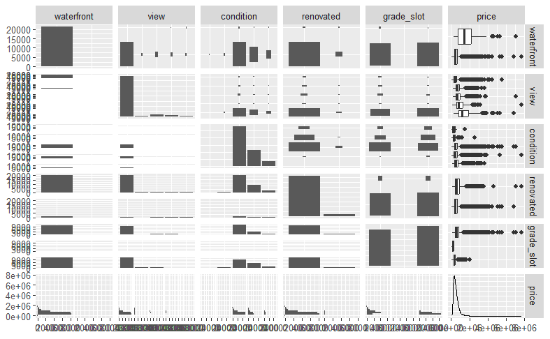

```r
ggpairs(houses_tidy_nonnumeric, progress = FALSE)
```

```r
model <- lm(price ~ waterfront + sqft_living + grade + view, housing_prices_trim)
```

```r
summary(model)
```

```
Call:
lm(formula = price ~ waterfront + sqft_living + grade + view,
    data = housing_prices_trim)

Residuals:
     Min       1Q   Median       3Q      Max
-1246178  -128328   -19963    97723  4850980

Coefficients:
                 Estimate Std. Error t value Pr(>|t|)
(Intercept)    -548548.70   12528.13  -43.78   <2e-16 ***
waterfrontTRUE  511759.81   22909.65   22.34   <2e-16 ***
sqft_living        165.30       2.72   60.77   <2e-16 ***
grade            94500.89    2104.58   44.90   <2e-16 ***
view1           167525.03   13037.18   12.85   <2e-16 ***
view2           111448.41    7849.42   14.20   <2e-16 ***
view3           177165.19   10737.54   16.50   <2e-16 ***
view4           383764.45   16632.09   23.07   <2e-16 ***
---
Signif. codes:  0 ‘***’ 0.001 ‘**’ 0.01 ‘*’ 0.05 ‘.’ 0.1 ‘ ’ 1

Residual standard error: 234800 on 21605 degrees of freedom
Multiple R-squared:  0.5911,    Adjusted R-squared:  0.591
F-statistic:  4462 on 7 and 21605 DF,  p-value: < 2.2e-16
```

# Correction and recap

## 1. What does 1 row represent?

1 house sold

## 2. understand the data

for example using a ‘skim()’ function

```r
houses <- read_csv("data/kc_house_data.csv")
houses
```

| id | date | price | bedrooms | bathrooms | sqft_living | sqft_lot | floors | waterfront | view | condition | grade | sqft_above | sqft_basement | yr_built | yr_renovated | zipcode | lat | long | sqft_living15 | sqft_lot15 |
| --- | --- | --- | --- | --- | --- | --- | --- | --- | --- | --- | --- | --- | --- | --- | --- | --- | --- | --- | --- | --- |
| 7129300520 | 2014-10-13 | 221900 | 3 | 1.00 | 1180 | 5650 | 1.0 | 0 | 0 | 3 | 7 | 1180 | 0 | 1955 | 0 | 98178 | 47.5112 | -122.257 | 1340 | 5650 |
| 6414100192 | 2014-12-09 | 538000 | 3 | 2.25 | 2570 | 7242 | 2.0 | 0 | 0 | 3 | 7 | 2170 | 400 | 1951 | 1991 | 98125 | 47.7210 | -122.319 | 1690 | 7639 |
| 5631500400 | 2015-02-25 | 180000 | 2 | 1.00 | 770 | 10000 | 1.0 | 0 | 0 | 3 | 6 | 770 | 0 | 1933 | 0 | 98028 | 47.7379 | -122.233 | 2720 | 8062 |
| 2487200875 | 2014-12-09 | 604000 | 4 | 3.00 | 1960 | 5000 | 1.0 | 0 | 0 | 5 | 7 | 1050 | 910 | 1965 | 0 | 98136 | 47.5208 | -122.393 | 1360 | 5000 |
| 1954400510 | 2015-02-18 | 510000 | 3 | 2.00 | 1680 | 8080 | 1.0 | 0 | 0 | 3 | 8 | 1680 | 0 | 1987 | 0 | 98074 | 47.6168 | -122.045 | 1800 | 7503 |
| 7237550310 | 2014-05-12 | 1225000 | 4 | 4.50 | 5420 | 101930 | 1.0 | 0 | 0 | 3 | 11 | 3890 | 1530 | 2001 | 0 | 98053 | 47.6561 | -122.005 | 4760 | 101930 |
| 1321400060 | 2014-06-27 | 257500 | 3 | 2.25 | 1715 | 6819 | 2.0 | 0 | 0 | 3 | 7 | 1715 | 0 | 1995 | 0 | 98003 | 47.3097 | -122.327 | 2238 | 6819 |
| 2008000270 | 2015-01-15 | 291850 | 3 | 1.50 | 1060 | 9711 | 1.0 | 0 | 0 | 3 | 7 | 1060 | 0 | 1963 | 0 | 98198 | 47.4095 | -122.315 | 1650 | 9711 |
| 2414600126 | 2015-04-15 | 229500 | 3 | 1.00 | 1780 | 7470 | 1.0 | 0 | 0 | 3 | 7 | 1050 | 730 | 1960 | 0 | 98146 | 47.5123 | -122.337 | 1780 | 8113 |
| 3793500160 | 2015-03-12 | 323000 | 3 | 2.50 | 1890 | 6560 | 2.0 | 0 | 0 | 3 | 7 | 1890 | 0 | 2003 | 0 | 98038 | 47.3684 | -122.031 | 2390 | 7570 |

[output cut: 990 more lines]

```r
skimr::skim(housing_prices)
```

```
── Data Summary ────────────────────────
                           Values
Name                       housing_prices
Number of rows             21613
Number of columns          21
_______________________
Column type frequency:
  character                1
  numeric                  19
  POSIXct                  1
________________________
Group variables            None
```

|  | skim_variable | n_missing | complete_rate | min | max | empty | n_unique | whitespace |
| --- | --- | --- | --- | --- | --- | --- | --- | --- |
| 1 | id | 0 | 1 | 10 | 10 | 0 | 21436 | 0 |

|  | skim_variable | n_missing | complete_rate | mean | sd | p0 | p25 | p50 | p75 | p100 | hist |
| --- | --- | --- | --- | --- | --- | --- | --- | --- | --- | --- | --- |
| 1 | price | 0 | 1 | 5.400881e+05 | 3.671272e+05 | 75000.0000 | 321950.000 | 450000.0000 | 645000.000 | 7700000.0000 | ▇▁▁▁▁ |
| 2 | bedrooms | 0 | 1 | 3.370842e+00 | 9.300618e-01 | 0.0000 | 3.000 | 3.0000 | 4.000 | 33.0000 | ▇▁▁▁▁ |
| 3 | bathrooms | 0 | 1 | 2.114757e+00 | 7.701632e-01 | 0.0000 | 1.750 | 2.2500 | 2.500 | 8.0000 | ▃▇▁▁▁ |
| 4 | sqft_living | 0 | 1 | 2.079900e+03 | 9.184409e+02 | 290.0000 | 1427.000 | 1910.0000 | 2550.000 | 13540.0000 | ▇▂▁▁▁ |
| 5 | sqft_lot | 0 | 1 | 1.510697e+04 | 4.142051e+04 | 520.0000 | 5040.000 | 7618.0000 | 10688.000 | 1651359.0000 | ▇▁▁▁▁ |
| 6 | floors | 0 | 1 | 1.494309e+00 | 5.399889e-01 | 1.0000 | 1.000 | 1.5000 | 2.000 | 3.5000 | ▇▅▁▁▁ |
| 7 | waterfront | 0 | 1 | 7.541757e-03 | 8.651720e-02 | 0.0000 | 0.000 | 0.0000 | 0.000 | 1.0000 | ▇▁▁▁▁ |
| 8 | view | 0 | 1 | 2.343034e-01 | 7.663176e-01 | 0.0000 | 0.000 | 0.0000 | 0.000 | 4.0000 | ▇▁▁▁▁ |
| 9 | condition | 0 | 1 | 3.409430e+00 | 6.507430e-01 | 1.0000 | 3.000 | 3.0000 | 4.000 | 5.0000 | ▁▁▇▃▁ |
| 10 | grade | 0 | 1 | 7.656873e+00 | 1.175459e+00 | 1.0000 | 7.000 | 7.0000 | 8.000 | 13.0000 | ▁▁▇▂▁ |

[output cut: 9 more lines]

|  | skim_variable | n_missing | complete_rate | min | max | median | n_unique |
| --- | --- | --- | --- | --- | --- | --- | --- |
| 1 | date | 0 | 1 | 2014-05-02 | 2015-05-27 | 2014-10-16 | 372 |

## 3. Featuring engineering

Taking the row materials we have and making them more useful (for example using a transformation).

It seems that the variables are positive distributed. This means that we could use a ‘log’ transformation in order to make them have a more ‘normal’ distribution form.

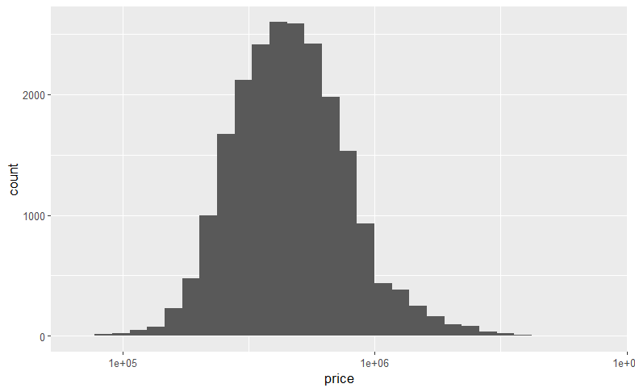

```r
houses %>%
  ggplot(aes(x = price))+
  geom_histogram()+
  scale_x_continuous(trans = "log10")
```

```r
houses_logged <- houses %>%
  mutate(ln_house_price = log(price))
```

For regression problems is not rare to have positive skewness, so the log transformation is often useful.

[figure not shown]

```r
houses_tidy <- houses %>%
  select(-c("id", "date", "sqft_living15", "sqft_lot15", "zipcode")) %>%
  mutate(waterfront = as.logical(waterfront)) %>%
  mutate(renovated = yr_renovated != 0) %>%
  select(-"yr_renovated") %>%
  mutate(view = as_factor(view)) %>%
  mutate(condition = as_factor(condition)) %>%
  mutate(grade = as_factor(grade))
```

[figure not shown]

```r
summary(lm(price ~ grade, houses_tidy))
```

```
Call:
lm(formula = price ~ grade, data = houses_tidy)

Residuals:
     Min       1Q   Median       3Q      Max
-1929615  -135853   -35090    89080  5565658

Coefficients:
            Estimate Std. Error t value Pr(>|t|)
(Intercept)   142000     254499   0.558 0.576878
grade3         63667     293870   0.217 0.828484
grade4         72381     258849   0.280 0.779767
grade5        106524     255024   0.418 0.676169
grade6        159920     254561   0.628 0.529868
grade7        260590     254513   1.024 0.305904
grade8        400853     254520   1.575 0.115285
grade9        631513     254547   2.481 0.013112 *
grade10       929771     254611   3.652 0.000261 ***
grade11      1354842     254817   5.317 1.07e-07 ***
grade12      2049222     255909   8.008 1.23e-15 ***
grade13      3567615     264106  13.508  < 2e-16 ***
---
Signif. codes:  0 ‘***’ 0.001 ‘**’ 0.01 ‘*’ 0.05 ‘.’ 0.1 ‘ ’ 1

Residual standard error: 254500 on 21601 degrees of freedom
Multiple R-squared:  0.5197,    Adjusted R-squared:  0.5195
F-statistic:  2125 on 11 and 21601 DF,  p-value: < 2.2e-16
```

```r
summary(lm(price ~ as.factor(grade), houses_tidy))
```

```
Call:
lm(formula = price ~ as.factor(grade), data = houses_tidy)

Residuals:
     Min       1Q   Median       3Q      Max
-1929615  -135853   -35090    89080  5565658

Coefficients:
                   Estimate Std. Error t value Pr(>|t|)
(Intercept)          142000     254499   0.558 0.576878
as.factor(grade)3     63667     293870   0.217 0.828484
as.factor(grade)4     72381     258849   0.280 0.779767
as.factor(grade)5    106524     255024   0.418 0.676169
as.factor(grade)6    159920     254561   0.628 0.529868
as.factor(grade)7    260590     254513   1.024 0.305904
as.factor(grade)8    400853     254520   1.575 0.115285
as.factor(grade)9    631513     254547   2.481 0.013112 *
as.factor(grade)10   929771     254611   3.652 0.000261 ***
as.factor(grade)11  1354842     254817   5.317 1.07e-07 ***
as.factor(grade)12  2049222     255909   8.008 1.23e-15 ***
as.factor(grade)13  3567615     264106  13.508  < 2e-16 ***
---
Signif. codes:  0 ‘***’ 0.001 ‘**’ 0.01 ‘*’ 0.05 ‘.’ 0.1 ‘ ’ 1

Residual standard error: 254500 on 21601 degrees of freedom
Multiple R-squared:  0.5197,    Adjusted R-squared:  0.5195
F-statistic:  2125 on 11 and 21601 DF,  p-value: < 2.2e-16
```

We note that the first group of grades is not statistically significant. Actually we said that also from the box plot. One possible thing to do could be that of grouping these first grades together and analyse the difference between that group and the other grades, which instead seems to be statistically significant.

## 4. ggpairs

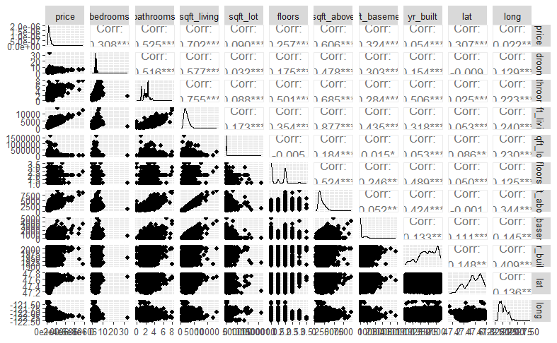

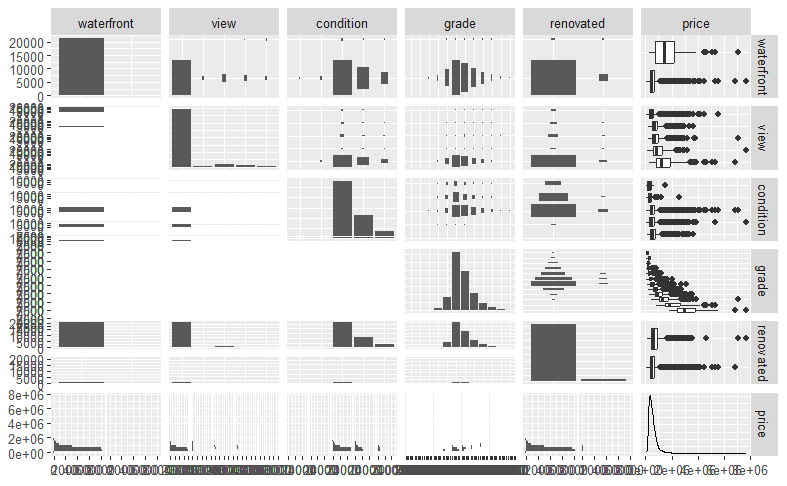

- we can `ggsave()` our `ggpairs` plots for seeing better them.

#### For the first grades’ factors which are not statistically significant, we could:

- group them together and compare them with the others
- `anova` test.
  - all or none

```r
mod1 <- lm(price ~ grade, houses_tidy)

mod2 <- lm(price ~ sqft_above + grade, houses_tidy)

houses_tidy %>%
  mutate(grade_grouped = as.factor(if_else(as.numeric(grade) < 8, 7, as.numeric(grade))))
```

| price | bedrooms | bathrooms | sqft_living | sqft_lot | floors | waterfront | view | condition | grade | sqft_above | sqft_basement | yr_built | lat | long | renovated | grade_grouped |
| --- | --- | --- | --- | --- | --- | --- | --- | --- | --- | --- | --- | --- | --- | --- | --- | --- |
| 221900 | 3 | 1.00 | 1180 | 5650 | 1.0 | FALSE | 0 | 3 | 7 | 1180 | 0 | 1955 | 47.5112 | -122.257 | FALSE | 7 |
| 538000 | 3 | 2.25 | 2570 | 7242 | 2.0 | FALSE | 0 | 3 | 7 | 2170 | 400 | 1951 | 47.7210 | -122.319 | TRUE | 7 |
| 180000 | 2 | 1.00 | 770 | 10000 | 1.0 | FALSE | 0 | 3 | 6 | 770 | 0 | 1933 | 47.7379 | -122.233 | FALSE | 7 |
| 604000 | 4 | 3.00 | 1960 | 5000 | 1.0 | FALSE | 0 | 5 | 7 | 1050 | 910 | 1965 | 47.5208 | -122.393 | FALSE | 7 |
| 510000 | 3 | 2.00 | 1680 | 8080 | 1.0 | FALSE | 0 | 3 | 8 | 1680 | 0 | 1987 | 47.6168 | -122.045 | FALSE | 7 |
| 1225000 | 4 | 4.50 | 5420 | 101930 | 1.0 | FALSE | 0 | 3 | 11 | 3890 | 1530 | 2001 | 47.6561 | -122.005 | FALSE | 10 |
| 257500 | 3 | 2.25 | 1715 | 6819 | 2.0 | FALSE | 0 | 3 | 7 | 1715 | 0 | 1995 | 47.3097 | -122.327 | FALSE | 7 |
| 291850 | 3 | 1.50 | 1060 | 9711 | 1.0 | FALSE | 0 | 3 | 7 | 1060 | 0 | 1963 | 47.4095 | -122.315 | FALSE | 7 |
| 229500 | 3 | 1.00 | 1780 | 7470 | 1.0 | FALSE | 0 | 3 | 7 | 1050 | 730 | 1960 | 47.5123 | -122.337 | FALSE | 7 |
| 323000 | 3 | 2.50 | 1890 | 6560 | 2.0 | FALSE | 0 | 3 | 7 | 1890 | 0 | 2003 | 47.3684 | -122.031 | FALSE | 7 |

[output cut: 990 more lines]

```r
anova(mod1, mod2)
```

```
Analysis of Variance Table

Model 1: price ~ grade
Model 2: price ~ sqft_above + grade
  Res.Df        RSS Df Sum of Sq      F    Pr(>F)
1  21601 1.3991e+15
2  21600 1.3681e+15  1   3.1e+13 489.45 < 2.2e-16 ***
---
Signif. codes:  0 ‘***’ 0.001 ‘**’ 0.01 ‘*’ 0.05 ‘.’ 0.1 ‘ ’ 1
```

```
Avvertimento: non si riesce a fare il plot senza sfruttarne uno:
   19453
```

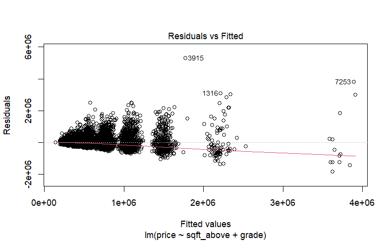

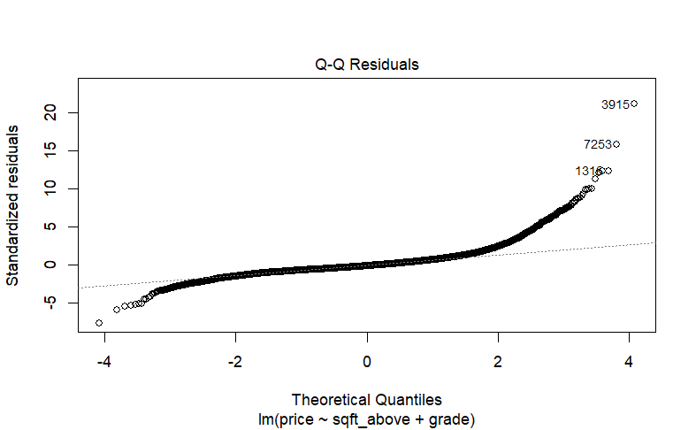

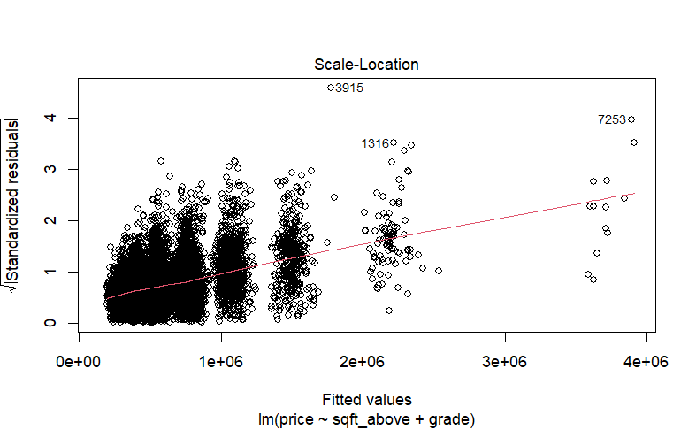

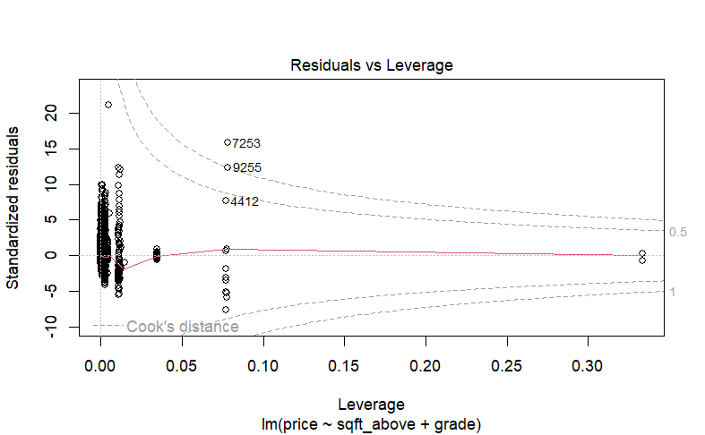

```r
plot(mod2)
```

Questions:

1. Is the model ready? From the first plot NO
2. Is the right model? I don’t know

Our first diagnostic plot is not ok!

Let’s have a look of the second: the QQ-plot.

(Alternative way. Plot residuals and see if they are normally distributed).

there is a symmetry but it seems right skeewed.

Third diagnostic plot:

how wrong are we? by our guess!

we want to be wrong of the same amount regardless of what we guess.

[output not shown]

[output cut: 990 more lines]

```r
summary(mod2)
```

```
Call:
lm(formula = price ~ sqft_above + grade, data = houses_tidy)

Residuals:
     Min       1Q   Median       3Q      Max
-1845587  -136387   -34657    89917  5291001

Coefficients:
             Estimate Std. Error t value Pr(>|t|)
(Intercept) 1.212e+05  2.517e+05   0.482   0.6301
sqft_above  7.177e+01  3.244e+00  22.123  < 2e-16 ***
grade3      4.166e+04  2.906e+05   0.143   0.8860
grade4      4.629e+04  2.560e+05   0.181   0.8565
grade5      5.954e+04  2.522e+05   0.236   0.8134
grade6      1.040e+05  2.517e+05   0.413   0.6794
grade7      1.803e+05  2.517e+05   0.716   0.4738
grade8      2.876e+05  2.517e+05   1.143   0.2532
grade9      4.690e+05  2.518e+05   1.862   0.0626 .
grade10     7.272e+05  2.519e+05   2.886   0.0039 **
grade11     1.099e+06  2.522e+05   4.357 1.32e-05 ***
grade12     1.736e+06  2.535e+05   6.851 7.55e-12 ***
grade13     3.153e+06  2.618e+05  12.043  < 2e-16 ***
---
Signif. codes:  0 ‘***’ 0.001 ‘**’ 0.01 ‘*’ 0.05 ‘.’ 0.1 ‘ ’ 1

Residual standard error: 251700 on 21600 degrees of freedom
Multiple R-squared:  0.5303,    Adjusted R-squared:  0.5301
F-statistic:  2033 on 12 and 21600 DF,  p-value: < 2.2e-16
```